# 栅格数据

Jianqi Huang

2023-03-08

```r
if (!require("pacman")) install.packages("pacman")
```

```r
pacman::p_load(
  terra, # handle raster data
  raster, # handle raster data
  exactextractr, # fast extractions
  sf, # vector data operations
  dplyr, # data wrangling
  tidyr, # data wrangling
  data.table, # data wrangling
  prism, # download PRISM data
  tictoc, # timing codes
  tigris, # to get county sf
  tmap # for mapping
)
```

## The element of geometry

### Points

```r
#--- create points ---#
point_1 <- st_point(c(2, 2))
point_2 <- st_point(c(1, 1))
point_3 <- st_point(c(1, 3))

#--- combine the points to make a single  sf of points ---#
(
  points <- list(point_1, point_2, point_3) %>%
    st_sfc() %>%
    st_as_sf() %>%
    mutate(point_name = c("point 1", "point 2", "point 3"))
)
```

```
## Simple feature collection with 3 features and 1 field
## Geometry type: POINT
## Dimension:     XY
## Bounding box:  xmin: 1 ymin: 1 xmax: 2 ymax: 3
## CRS:           NA
##             x point_name
## 1 POINT (2 2)    point 1
## 2 POINT (1 1)    point 2
## 3 POINT (1 3)    point 3
```

### Lines

```r
#--- create points ---#
line_1 <- st_linestring(rbind(c(0, 0), c(2.5, 0.5)))
line_2 <- st_linestring(rbind(c(1.5, 0.5), c(2.5, 2)))

#--- combine the points to make a single  sf of points ---#
(
lines <- list(line_1, line_2) %>%
  st_sfc() %>%
  st_as_sf() %>%
  mutate(line_name = c("line 1", "line 2"))
)
```

```
## Simple feature collection with 2 features and 1 field
## Geometry type: LINESTRING
## Dimension:     XY
## Bounding box:  xmin: 0 ymin: 0 xmax: 2.5 ymax: 2
## CRS:           NA
##                             x line_name
## 1   LINESTRING (0 0, 2.5 0.5)    line 1
## 2 LINESTRING (1.5 0.5, 2.5 2)    line 2
```

### Polygons

```r
#--- create polygons ---#
polygon_1 <- st_polygon(list(
  rbind(c(0, 0), c(2, 0), c(2, 2), c(0, 2), c(0, 0))
))

polygon_2 <- st_polygon(list(
  rbind(c(0.5, 1.5), c(0.5, 3.5), c(2.5, 3.5), c(2.5, 1.5), c(0.5, 1.5))
))

polygon_3 <- st_polygon(list(
  rbind(c(0.5, 2.5), c(0.5, 3.2), c(2.3, 3.2), c(2, 2), c(0.5, 2.5))
))

#--- combine the polygons to make an sf of polygons ---#
(
polygons <- list(polygon_1, polygon_2, polygon_3) %>%
  st_sfc() %>%
  st_as_sf() %>%
  mutate(polygon_name = c("polygon 1", "polygon 2", "polygon 3"))
)
```

```
## Simple feature collection with 3 features and 1 field
## Geometry type: POLYGON
## Dimension:     XY
## Bounding box:  xmin: 0 ymin: 0 xmax: 2.5 ymax: 3.5
## CRS:           NA
##                                x polygon_name
## 1 POLYGON ((0 0, 2 0, 2 2, 0 ...    polygon 1
## 2 POLYGON ((0.5 1.5, 0.5 3.5,...    polygon 2
## 3 POLYGON ((0.5 2.5, 0.5 3.2,...    polygon 3
```

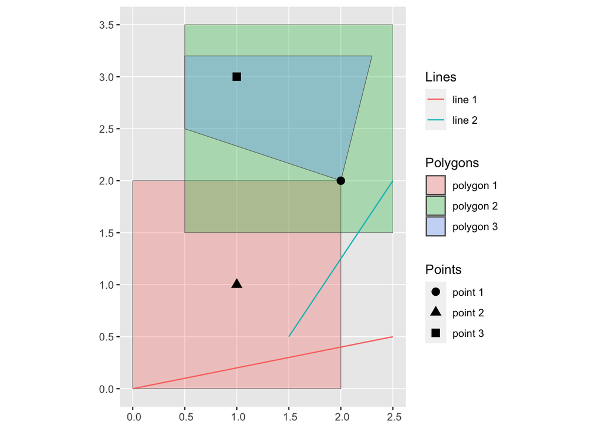

```r
ggplot() +
  geom_sf(data = polygons, aes(fill = polygon_name), alpha = 0.3) +
  scale_fill_discrete(name = "Polygons") +
  geom_sf(data = lines, aes(color = line_name)) +
  scale_color_discrete(name = "Lines") +
  geom_sf(data = points, aes(shape = point_name), size = 3) +
  scale_shape_discrete(name = "Points")
```

`geom_sf`来对于各种元素进行绘制。

#### `st_intersects`

这个函数能够识别`sfg`对象与`sfg`进行交互。实际上就是取交集。

```r
st_intersects(points, polygons)
```

```
## Sparse geometry binary predicate list of length 3, where the predicate
## was `intersects'
##  1: 1, 2, 3
##  2: 1
##  3: 2, 3
```

```r
st_intersects(points, polygons, sparse = FALSE)
```

```
##       [,1]  [,2]  [,3]
## [1,]  TRUE  TRUE  TRUE
## [2,]  TRUE FALSE FALSE
## [3,] FALSE  TRUE  TRUE
```

polygons and polygons

```r
st_intersects(polygons, polygons)
```

```
## Sparse geometry binary predicate list of length 3, where the predicate
## was `intersects'
##  1: 1, 2, 3
##  2: 1, 2, 3
##  3: 1, 2, 3
```

```r
set.seed(38424738)

points_set_1 <- lapply(1:5, function(x) st_point(runif(2))) %>%
  st_sfc() %>% st_as_sf() %>%
  mutate(id = 1:nrow(.))

points_set_2 <- lapply(1:5, function(x) st_point(runif(2))) %>%
  st_sfc() %>% st_as_sf() %>%
  mutate(id = 1:nrow(.))
```

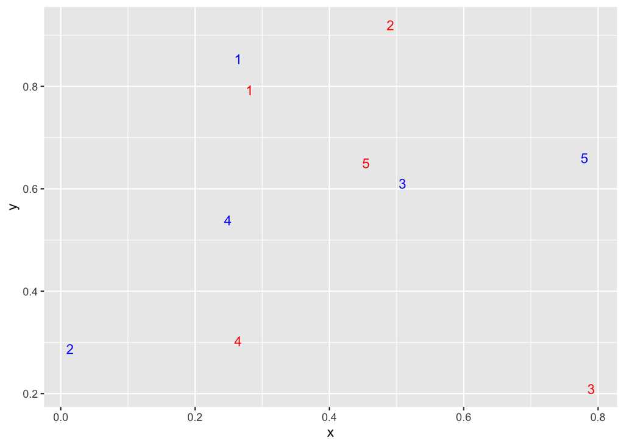

```r
ggplot() +
  geom_sf_text(data = points_set_1, aes(label = id), color = "red") +
  geom_sf_text(data = points_set_2, aes(label = id), color = "blue")
```

我们可以使用`st_buffer`来构建一个buffer对象，本质上还是一个polygon对象。

```r
#--- create 0.2 buffers around points in points_set_1 ---#
buffer_1 <- st_buffer(points_set_1, dist = 0.2)
buffer_1
```

```
## Simple feature collection with 5 features and 1 field
## Geometry type: POLYGON
## Dimension:     XY
## Bounding box:  xmin: 0.06416073 ymin: 0.009454859 xmax: 0.989738 ymax: 1.119881
## CRS:           NA
##                                x id
## 1 POLYGON ((0.4809702 0.79300...  1
## 2 POLYGON ((0.6907635 0.91988...  2
## 3 POLYGON ((0.989738 0.209454...  3
## 4 POLYGON ((0.4641607 0.30318...  4
## 5 POLYGON ((0.6544901 0.64992...  5
```

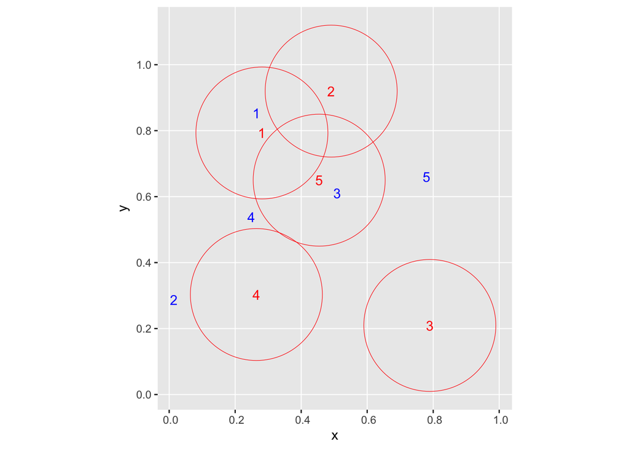

```r
ggplot() +
  geom_sf(data = buffer_1, color = "red", fill = NA) +
  geom_sf_text(data = points_set_1, aes(label = id), color = "red") +
  geom_sf_text(data = points_set_2, aes(label = id), color = "blue")
```

## raster

什么是栅格数据？在[ArcMap](https://desktop.arcgis.com/zh-cn/arcmap/latest/manage-data/raster-and-images/what-is-raster-data.htm)中的定义为

> 最简形式的栅格由按行和列（或格网）组织的像元（或像素）矩阵组成，其中的每个像元都包含一个信息值（例如温度）。栅格可以是数字航空像片、卫星影像、数字图片或甚至扫描的地图。

以栅格格式存储的数据可以表示各种实际现象：

- 专题数据（也称为离散数据）表示土地利用或土壤数据等要素。
- 连续数据表示温度、高程或光谱数据（例如，卫星影像或航空像片）等现象。
- 图片则包括扫描的地图或绘图，以及建筑物照片。

```r
library(raster)
```

一个最简单的栅格数据创建方法：

```r
x1 <- raster()
x1
```

```
## class      : RasterLayer
## dimensions : 180, 360, 64800  (nrow, ncol, ncell)
## resolution : 1, 1  (x, y)
## extent     : -180, 180, -90, 90  (xmin, xmax, ymin, ymax)
## crs        : +proj=longlat +datum=WGS84 +no_defs
```

指定维度与数据范围

```r
x2 <- raster(nrows = 18, ncols = 36,
             xmn = -900, xmx = 900,
             ymn = -900, ymx = 900)
x2
```

```
## class      : RasterLayer
## dimensions : 18, 36, 648  (nrow, ncol, ncell)
## resolution : 50, 100  (x, y)
## extent     : -900, 900, -900, 900  (xmin, xmax, ymin, ymax)
## crs        : NA
```

指定数据范围与分辨率

```r
x3 <- raster(xmn = -900, xmx = 900,
             ymn = -900, ymx = 900,
             resolution = c(50, 100))
x3
```

```
## class      : RasterLayer
## dimensions : 18, 36, 648  (nrow, ncol, ncell)
## resolution : 50, 100  (x, y)
## extent     : -900, 900, -900, 900  (xmin, xmax, ymin, ymax)
## crs        : NA
```

指定维度与分辨率

```r
x4 <- raster(nrows = 18, ncols = 36,
             resolution = c(50, 100))
x4
```

```
## class      : RasterLayer
## dimensions : 2, 7, 14  (nrow, ncol, ncell)
## resolution : 50, 100  (x, y)
## extent     : -180, 170, -110, 90  (xmin, xmax, ymin, ymax)
## crs        : +proj=longlat +datum=WGS84 +no_defs
```

```r
x4$layer$values=c(36*1:18)
x4
```

[output not shown]

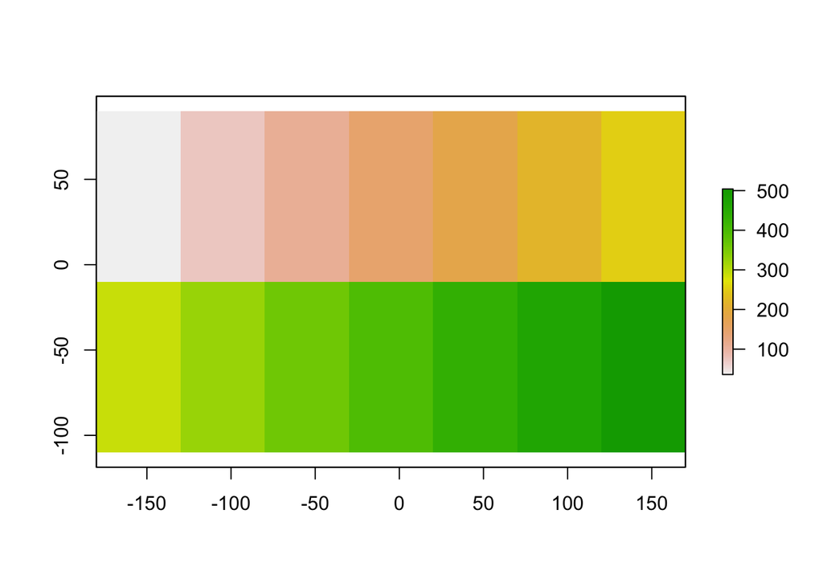

```r
plot(x4)
```

## 多图层栅格数据

栅格数据可以使用多层来进行叠加，`stack()`就是一个创建栅格数据合并为一个栅格数据的函数。

```r
r1 <- raster(ncols = 3, nrows = 3,
             vals = c(1:9))
r2 <- raster(ncols = 3, nrows = 3,
             vals = rep(c(0,1,2), 3))
r <- stack(r1, r2)
r
```

```
## class      : RasterStack
## dimensions : 3, 3, 9, 2  (nrow, ncol, ncell, nlayers)
## resolution : 120, 60  (x, y)
## extent     : -180, 180, -90, 90  (xmin, xmax, ymin, ymax)
## crs        : +proj=longlat +datum=WGS84 +no_defs
## names      : layer.1, layer.2
## min values :       1,       0
## max values :       9,       2
```

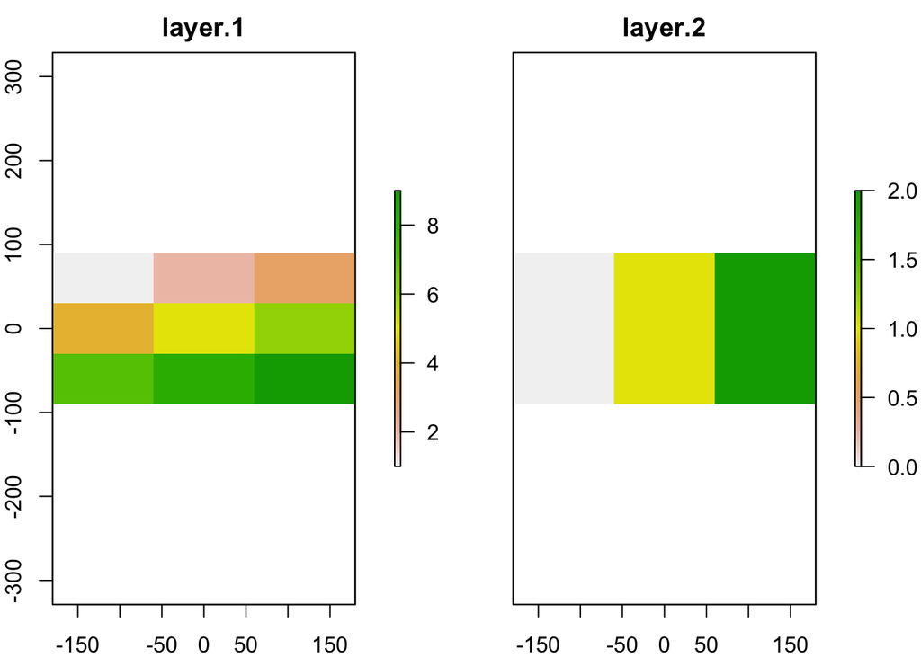

```r
plot(r)
```

## 代数运算

```r
r1 <- raster(ncols = 3, nrows = 3,
             vals = c(1:9))
r2 <- raster(ncols = 3, nrows = 3,
             vals = rep(c(0,1,2), 3))
getValues(r1)
```

```
## [1] 1 2 3 4 5 6 7 8 9
```

```r
getValues(r2)
```

```
## [1] 0 1 2 0 1 2 0 1 2
```

## 可视化

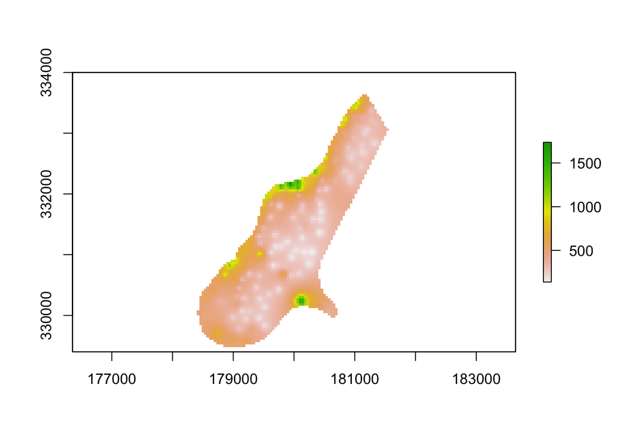

```r
filename <- system.file("external/test.grd", package="raster")
r <- raster(filename)
plot(r)
```

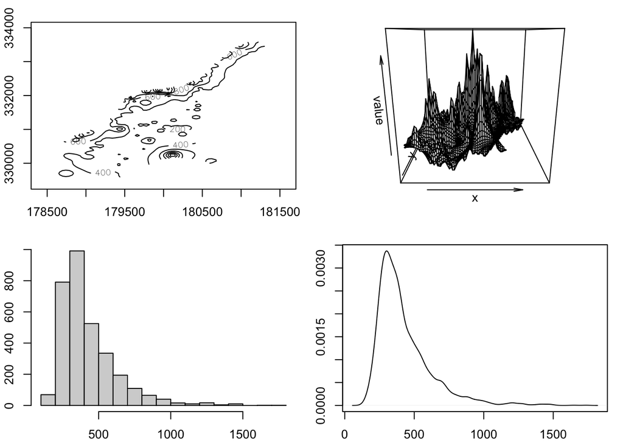

```r
par(mfrow = c(2,2), plt = c(0.1,0.95,0.15,0.9))
contour(r)
persp(r)
hist(r)
density(r)
```

To be precise, here is what we mean by raster data extraction and what it does for points and polygons data:

- Points: For each of the points, find which raster cell it is located within, and assign the value of the cell to the point.
- Polygons: For each of the polygons, identify all the raster cells that intersect with the polygon, and assign a vector of the cell values to the polygon